# Презентация по лабораторной работе № 4

Дискреционное разграничение прав в Linux. Расширенные атрибуты

Неустроева И.Н.

Российский университет дружбы народов, Москва, Россия

28 февраля 2025

# Информация

## Докладчик

- Неустроева Ирина Николаевна
- студентка группы НБИ 02-23
- Российский университет дружбы народов
- https://inneustroeva.github.io/ru/

# Вводная часть

## Цели и задачи

Получение практических навыков работы в консоли с расширенными атрибутами файлов

## Материалы и методы

- Процессор `pandoc` для входного формата Markdown
- Результирующие форматы
  - `pdf`
  - `html`
- Автоматизация процесса создания: `Makefile`

# Основная часть

## Расширенные атрибуты

От имени пользователя guest определили расширенные атрибуты файла /home/guest/dir1/file1

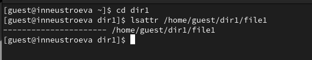

## Право на чтение и запись для владельца

Установили на файл file1 права, разрешающие чтение и запись для владельца файла.

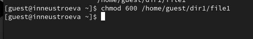

## Расширенный атрибут а от имени guest

Попробовали установить на файл /home/guest/dir1/file1 расширенный атрибут a от имени пользователя guest, отказ в доступе

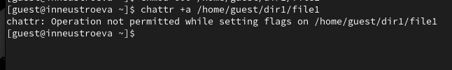

## Расширенный атрибут от имени суперпользователя

Попробовали установить на файл /home/guest/dir1/file1 расширенный атрибут a от имени пользователя суперпользователя, получилось это сделать

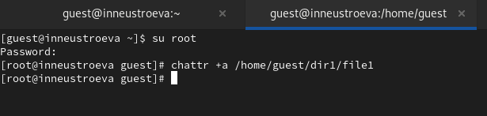

## Работа с файлом

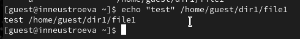

## Работа с файлом

Попробовали установить на файл file1 права, запрещающие чтение и запись для владельца файл, тоже получили отказ

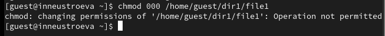

## Снятие атрибута

Сняли расширенный атрибут a с файла /home/guest/dirl/file1 от имени суперпользователя

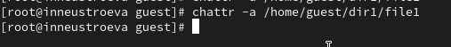

## Доступно установление прав для файла

Снова пробуем установить на файл file1 права, запрещающие чтение и запись для владельца файл, это нам удаеться, также можем его переименовать.

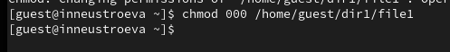

## Замена атрибута

Заменили атрибут «a» атрибутом «i»

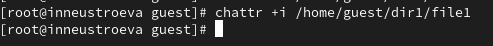

## Отказ в доступе

Видим, что при попытке удалить файл, нам отказанно в доступе. Также мы не можем его перемещать и изменение прав доступа тоже невозможно. Таким образом, файл можно лишь читать, в таком режиме он менее уязвим.

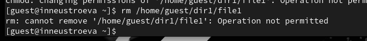

## Вывод

Получили практические навыки работы в консоли с расширенными атрибутами файлов.